# Parásitos

# El octavo pasajero

> Un parásito es un depredador muy sofisticado. No se conforma con abrir la boca y comerse a uno más pequeño o arrancarle un trozo a uno más grande, sino que es capaz de explotar a su presa, el hospedador, sin matarla. En el cine hemos visto versiones más ineptas de esta estrategia, donde un alien incuba sus descendientes dentro de los hospedadores, cargándoselos finalmente. En realidad, «Alien» era un parasitoide. Los auténticos parásitos tienen tácticas mucho más sofisticadas, tan diversas y sorprendentes que sobrepasan el ámbito de la ecología teórica. Así que nos conformaremos con explorar las orillas matemáticas del asunto.

## ¿Qué diferencia hay entre un depredador y un parásito?

Cualquiera distingue entre una pulga y un zorro aunque, matemáticamente, son completamente equivalentes: ambos crecen a expensas del conejo. Piénsalo un poco y llegarás a las mismas ecuaciones. Entonces, ¿por qué se le dedica un apartado especial a esta forma de vida? Seguramente porque la forma de las ecuaciones y los coeficientes se puenden interpretar de forma mucho más intuiva.

En efecto así fue: en busca de ecuaciones más intuitivas que las abstractas diferenciales de Lotka y Volterra, apenas diez años después que estos, el entomólogo australiano Alexander Nicholson y su amigo el físico Victor Bailey describieron un [modelo de interacción entre un hospedador y un parásito](https://zslpublications.onlinelibrary.wiley.com/doi/10.1111/j.1096-3642.1935.tb01680.x) mucho más natural, partiendo de axiomas muy sencillos y al alcance de cualquier biólogo.

### Las reglas más sencillas

No se necesitan ecuaciones para emular el comportamiento de un parásito que se aprovecha de su hospedador. Basta con unas sencillas reglas. Mira:

[video not shown]

**El ladrón de cuerpos.** Los individuos que actúan como hospedadores ● se multiplican por 2 en cada generación mientras no sean infestados por el parásito ●. En este caso, se transformarán en ● portadores de nuevos parásitos. En la nueva generación, en vez de dos nuevos hospedadores, de cada portador saldrán 2 parásitos. Estas sencillas reglas generan una dinámica oscilante que puede recordarnos a la del modelo depredador/presa de Lotka-Volterra. No obstante, la naturaleza de ambos sistemas es completamente distinta.

## «Los ladrones de cuerpos»

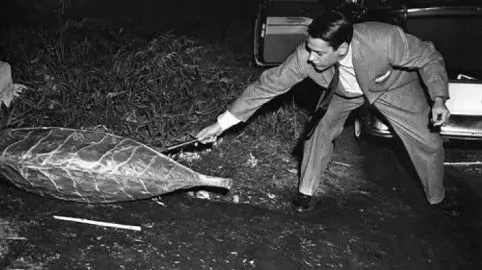

El parásito, literalmente, roba el cuerpo del hospedador y lo somete a su beneficio como fábrica de nuevos parásitos. A veces solo lo explota como alimento y lo consume por completo, matándolo. Otras veces, el parásito desarrolla una estrategia más elaborada que puede, incluso, cambiar el comportamiento del hospedador haciendo que trabaje a favor del primero, por ejemplo, deteniendo el desarrollo de la oruga hospedador y alargando su existencia hasta dejarla exhausta. A los organismos que actúan así se les suele llamar «parasitoides» y se deja el epíteto «parásito» para los que viven indefinidamente con su hospedador, causándole cierto menoscabo pero sin llegar a matarlo, como las pulgas del conejo.

> Alien era un «parasitoide»

# El modelo de Nicholson & Bailey

Los dos australianos diseñaron un modelo basado en las generaciones discretas propias de insectos, partiendo de los axiomas:

- El hospedador crece geométricamento con una tasa $\lambda$ en ausencia de parásitos.
- El parásito se reproduce infestando huevos o larvas del hospedador, de cada uno de los cuales saldrán $c$ nuevos parásitos.
- En cada puesta hay una fracción $f$ que se libra de ser infestada.

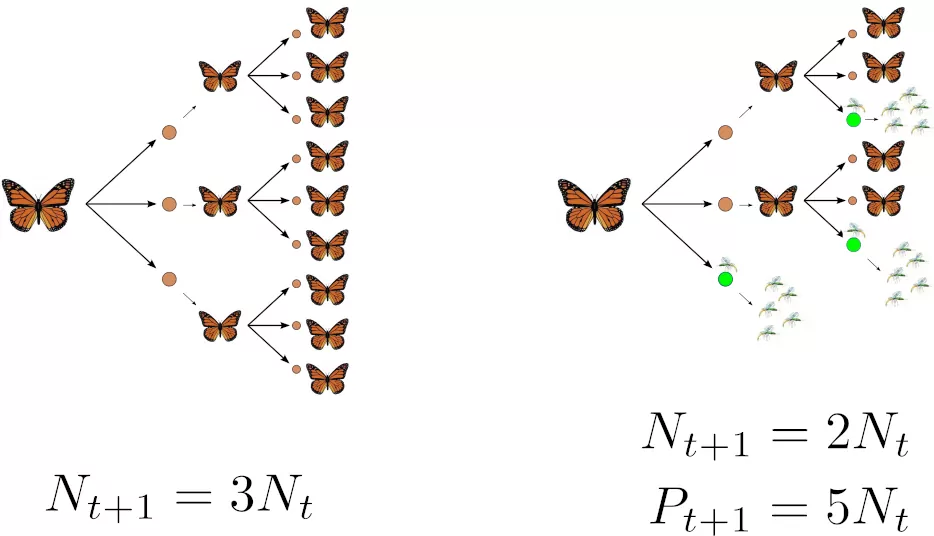

**Figura 1. Resultado de los axiomas.** Si cada mariposa pone 3 huevos, la siguiente generación tendrá el triple de individuos. Si aparece un parásito que infesta $\frac{1}{3}$ de los huevos con 5 descendientes suyos, en la siguiente generación solo se duplicará el número de mariposas y por cada mariposa infestada aparecerán 5 parásitos. En este ejemplo, $\lambda = 3$, $c = 5$ y $f = \frac{2}{3}$.

## Planteamiento general

Es fácil deducir las ecuaciones del caso general:

$$\begin{align}
N_{t+1} &= \lambda f N_t \\[1em]
P_{t+1} &= c \lambda (1 - f) N_t
\end{align}$$

donde $N_t$ y $P_t$ son, respectivamente, las abundancias de hospedadores y parásitos en la generación $t$.

Date cuén de que son ecuaciones discretas: dan directamente el número de individuos de la siguiente generación, en vez de la velocidad de cambio como las ecuaciones diferenciales. Esto implica, además, que no hay una expresión explícita del tiempo: solo cuentan las generaciones.

A primera vista, sorprende que la abundancia de parásitos solo dependa de la densidad de hospedadores de la generación anterior y que éstos no dependan de los parásitos. ¿No importa el número de parásitos que convive con el hospedador? Ya veremos dentro de un rato…

¿Basta la presencia del parásito para frenar la tendencia al crecimiento exponencial del hospedador? Si así fuese, en algún momento debería mantenerse constante $N_t$, es decir, se debe cumplir que $N_{t+1} = N_t$. Para que esto ocurra, debe cumplirse que

$$\lambda = \frac{1}{f}$$

que se comprende fácilmente: todo lo que crecería el hospedador es explotado por el parásito. Y dado que $P$ solo depende de $N$, cuando el hospedador esté en equilibrio, también lo estará el parásito.

## Efecto del número de parásitos

De alguna forma debería importar la densidad de parásitos. Veamos una aproximación intuitiva:

[figure not shown]

**Figura 2. Efecto del número de parásitos.** Cada cuadrado representa un huevo del hospedador. Suponiendo que 10 parásitos encuentran su víctima al azar, lo más probable es que otros tantos hospedadores se vean afectados (primera imagen a la izquierda); en este caso, $f = \frac{9}{10}$. Si se duplica el número de parásitos se podría esperar que $f$ disminuyera a $0.8$, pero no es así porque los parásitos pican al azar y aumenta la probabilidad de que pinchen en el mismo hospedador, así que $f$ disminuye, pero no en proporción a $P$. Cuando mayor sea $P$ menor será $f$. Observa cómo aún con $P = 100$ quedan algunos hospedadores sin infestar. *¿Hay alguna regla para aplicar este efecto?*

#### Distribución de Poisson

[figure not shown]

Podemos ver $f$ como la probabilidad de que ningún parásito infeste a un hospedador. ¿Habrá alguna forma de deducirla?

Consideremos la probabilidad contraria: la de que un parásito infeste con éxito a un hospedador y la llamamos $a$. Si solo hubiese un parásito, está claro que la probabilidad de librarse $f$ es la complementaria:

$$f_1 = 1 - a$$

Bien, pero llega otro parásito, idéntico al primero. ¿Cuál es ahora la probabilidad de seguir librándose? Habrá que multiplicar otra vez por la probabilidad unitaria:

$$f_2 = (1 - a)(1 - a) = (1 - a)^2$$

Y así, en general, la probabilidad de librarse del ataque de $P$ parásitos es

$$f = (1 - a)^P$$

Esta expresión ya vale para nuestro propósito. No obstante, podemos modificarla un poco más porque así es difícil de usar, sobre todo para calcular las densidades en equilibrio. Vamos a aprovechar que, cuando $a$ es cercana a cero, se cumple

$$\ln(1 - a) \approx -a$$

Entonces, multiplicando ambos lados por $P$:

$$P\ln(1 - a) \approx -a P$$

y elevando a $e$:

$$e^{P\ln(1 - a)} \approx e^{-a P}$$

reordenamos un poco:

$$[e^{\ln(1 - a)}]^P \approx e^{-a P}$$

y tenemos lo que buscamos:

$$(1 - a)^P \approx e^{-a P}$$

Es decir, la probabilidad que buscamos es

$$f = e^{-a P}$$

No te sorprenderá saber que Gause ya describió, intuitivamente, una expresión muy parecida en su *Lucha por la existencia* (pág. 55) cuando escribe sobre la tasa de encuentros entre depredadores y presas.

Puedes comprobar la validez de la aproximación, con distintos valores de $a$ aquí abajo.

[interactive chart not shown]

**Aproximación de $f$.** Para valores bajos de $a$ y suficientemente altos de $P$ la aproximación exponencial al valor exacto es muy buena. Tanto que Poisson la utilizó para simplificar su famosa distribución, basada en una sucesión de binomiales con valor de probabilidad muy baja (por eso se conoce, a veces, como *distribución de los casos raros*). Nosotros solo necesitamos el primer término de la distribución, aquél que da la probabilidad de que un hospedador obtenga 0 picotazos, es decir, $f$.

## Ecuaciones y dinámica

Con la expresión de $f$ ya podemos escribir las ecuaciones definivas:

$$\begin{align}
N_{t+1} &= \lambda N_t e^{-a P_t}\\[1em]
P_{t+1} &= c \lambda N_t (1 - e^{-a P_t})
\end{align}$$

y probarlas en la Figura 3.

[interactive chart not shown]

**Figura 3. Dinámica del modelo original de Nicholson & Bailey.** A la izquierda, la dinámica temporal del hospedador ● y el parásito ●. A la derecha tienes el espacio de fases con las nuliclinas de ambas especies (en el siguiente apartado las calcularemos). Puedes elegir las abundancias iniciales y el valor de los coeficientes que, por mucho que lo intentes, será imposible encontrar un equilibrio estable, a no ser que atines exactamente con los valores exactos.

## Equilibrio

Ya habrás comprobado que la dinámica tiende a divergir y siempre acaba con la extinción del hospedador o el parásito. Aún así existe un equilibrio teórico que se puede calcular a partir de la condición $\lambda = \frac{1}{f}$ que vimos antes. Sustituyendo $f$ por su valor tenemos

$$\lambda = \frac{1}{e^{-a P}}$$

es decir,

$$\lambda = e^{a P}$$

y, despejando $P$, obtenemos la abundancia de parásitos que equilibra el crecimiento del hospedador:

$$P = \frac{\ln \lambda}{a}$$

Para saber la densidad de hospedadores en equilibrio utilizamos la segunda ecuación. Como $N$ está en equilibrio, también debe estarlo $P$:

$$P = c \lambda N (1 - e^{-a P})$$

Así que despejamos $N$:

$$N = \frac{P}{c \lambda (1 - e^{-a P})}$$

y sustituimos $P$ por su valor en equilibrio,

$$N = \frac{\frac{\ln \lambda}{a}}{c \lambda (1 - e^{-a \frac{\ln \lambda}{a}})}$$

que es más aparatoso que complicado:

$$N = \frac{\ln \lambda}{a c \lambda (1 - e^{-\ln \lambda})} = \frac{\ln \lambda}{a c \lambda (1 - \frac{1}{\lambda})}$$

y, finalmente,

$$N = \frac{\ln \lambda}{a c (\lambda - 1)}$$

El mismo desarrollo se puede hacer con el valor exacto de $f$, aunque las expresiones finales son monstruosas y no se pueden simplificar.

La existencia de este equilibrio indica que *es posible* que un parásito frene el crecimiento exponencial del hospedador. En la práctica, sin embargo, ello es muy poco probable pues se trata de un equilibrio inestable.

### ¿De qué generación soy?

Nuestra intuición puede interpretar el asunto de, al menos, dos formas distintas de las que salen ecuaciones distintas (aunque equivalentes). La que seguimos aquí, donde se separan las generaciones del hospedador por las puestas de huevos, y otra más condensada que obvia el paso intermedio. Mira de nuevo la Figura 1, donde suponemos $\lambda = 3$, $f = \frac{2}{3}$ y $c = 5$, ahora con más detalles:

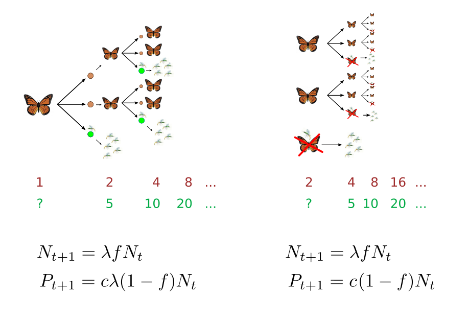

En la formulación abreviada se elimina directamente la fracción $1 - f$ de hospedadores y se sustituye en la generación posterior por $c$ parásitos. Esto tiene un efecto sobre la generación donde aparecen los parásitos, que se retrasa una con respecto a los hospedadores. La segunda ecuación, por tanto, pierde el factor $\lambda$.

No te preocupes, porque no tiene la más mínima importancia, salvo el desfase en la nomenclatura de las generaciones. ¡Ah, y también en el equilibrio de los hospedadores que, como van adelantados una generación en esta nomenclatura, ahora es

$$N = \frac{\lambda \ln \lambda}{a c (\lambda - 1)}$$

Esta fórmula tal vez es más común en la literatura, pero es fácil encontrar ambas. Tú puedes elegir la que más te guste, o la que mejor encaje con tu visión del mecanismo del parásito. No afecta a ninguna propiedad del modelo.

##### El experimento de Burnett

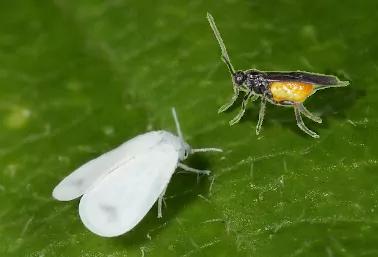

El entomógolo canadiense Thomas Burnett, decidido a comprobar experimentalmente la dinámica de Nicholson & Bailey, realizó a mediados del siglo pasado un experimento muy peculiar que dio a conocer en el [X Congreso Internacional de Entomología](https://www.icecouncil.org/), celebrado en Montreal en 1956. El experimento se puede resumir así:

- Puso unas cuantas mosquillas blancas *Trialeurodes vaporariorum* y añadió otras pocas avispillas *Encarsia formosa*, parásitas de las anteriores.
- Cada dos días contaba las trialeurodes infestadas y no infestadas.
- Retiraba las infestadas y las sustituía por el mismo número de encarsias adultas.
- Al mismo tiempo, duplicaba la cantidad de trialeurodes no afectadas añadiendo indéntico número.

Era una forma artificial de obtener «generaciones» de una forma muy rápida y asegurar que ambas poblaciones seguirían la dinámica de N&B. Aquí tienes los resultados:

| «Generación» | Trialeurodes | Encarsias |
| --- | --- | --- |
| 0 | 19 | 8 |
| 1 | 17 | 9 |
| 2 | 15 | 8 |
| 3 | 14 | 7 |
| 4 | 15 | 7 |
| 5 | 16 | 6 |
| 6 | 21 | 6 |
| 7 | 28 | 7 |
| 8 | 30 | 11 |
| 9 | 22 | 14 |
| 10 | 11 | 13 |
| 11 | 8 | 7 |
| 12 | 10 | 4 |
| 13 | 13 | 4 |
| 14 | 20 | 5 |
| 15 | 33 | 6 |
| 16 | 45 | 10 |
| 17 | 37 | 14 |
| 18 | 22 | 17 |
| 19 | 13 | 24 |
| 20 | 5 | 11 |
| 21 | 4 | 4 |
| 22 | 5 | 2 |

Veamos sus resultados con un breve *script* en **R**

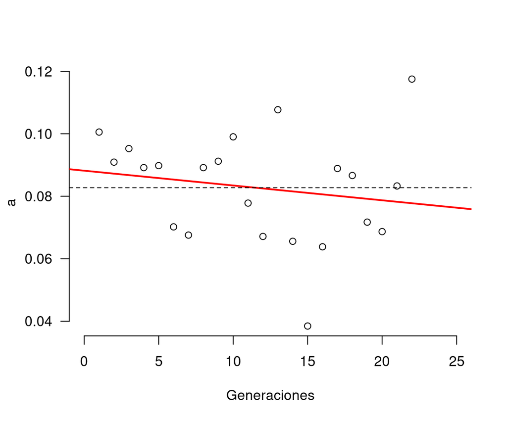

```r
N <- c(19, 17, 15, 14, 15, 16, 21, 28, 30, 22, 11, 8, 10, 13, 20, 33, 45, 37, 22, 13, 5, 4, 5)    # trialeurodes
P <- c(8, 9, 8, 7, 7, 6, 6, 7, 11, 14, 13, 7, 4, 4, 5, 6, 10, 14, 17, 24, 11, 4, 2)    # encarsias
a <- log(2*N[1:22]/N[2:23]) / P[1:22]
amed <- mean(a)
plot(1:22, a, xlim = c(0, 25), bty = "n", las = 1, xlab = "Generaciones")
ajuste <- lm(a~seq(1,22))
abline(ajuste, col = "red", lwd = 2)
abline(h = amed, lty = 2)
```

**Valores estimados de $a$** a partir de abundancias consecutivas. El valor medio es $a = 0.083$ (línea discontinua) y, aunque muestra una ligera tendencia a disminuir conforme avanzan las generaciones (línea roja), no es muy significativa.

Con este valor de $a$ y los impuestos a $\lambda$ y $c$, calculó los valores teóricos según las ecuaciones de Nicholson y Bailey. Nosotros, además de esto, podemos ajustar *todos los coeficientes* mediante optimización, ¿saldrá algo parecido?

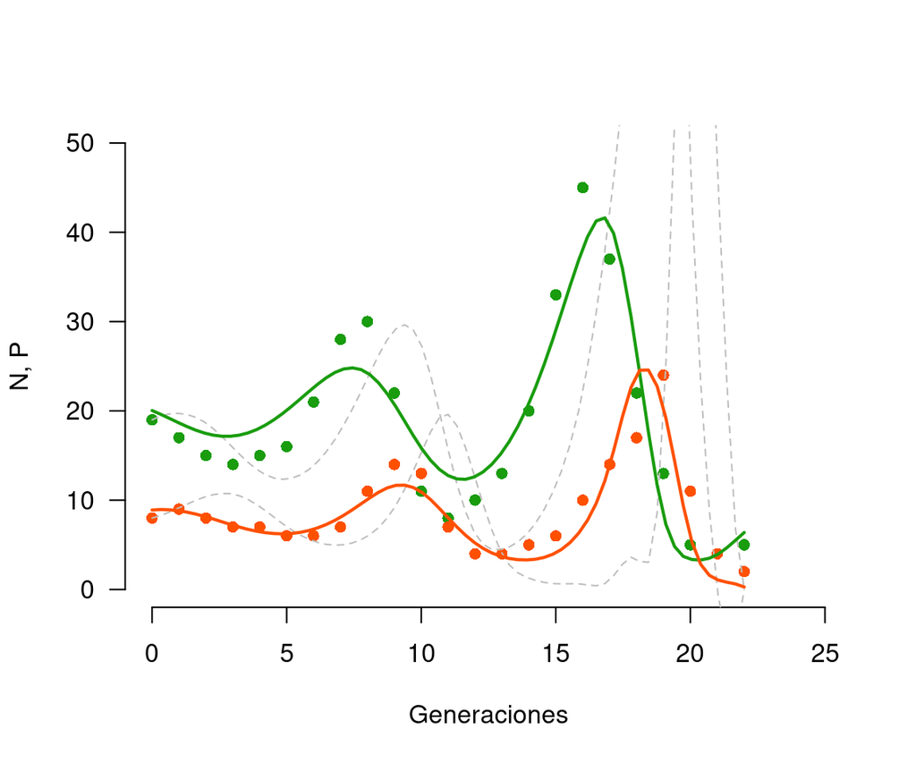

```r
# AJUSTE POR OPTIMIZACIÓN Y COMPARACIÓN CON LA ESTIMACIÓN DE BURNETT

N <- c(19, 17, 15, 14, 15, 16, 21, 28, 30, 22, 11, 8, 10, 13, 20, 33, 45, 37, 22, 13, 5, 4, 5)    # trialeurodes
P <- c(8, 9, 8, 7, 7, 6, 6, 7, 11, 14, 13, 7, 4, 4, 5, 6, 10, 14, 17, 24, 11, 4, 2)    # encarsias
a <- log(2*N[1:22]/N[2:23]) / P[1:22]
amed <- mean(a)

# función que calcula la simulación de NB
NB <- function(t, par) {
  # t: generaciones
  # par[4], par[5]: valores iniciales N, P
  # par[1]: lambda
  # par[2]: a
  # par[3]: c
  Nt <- numeric()
  Pt <- numeric()
  Nt[1] <- par[4]
  Pt[1] <- par[5]
  for (i in 2:t) {
    f <- exp(-par[2]*Pt[i-1])
    Nt[i] <- par[1]*Nt[i-1]*f
    Pt[i] <- par[3]*par[1]*Nt[i-1]*(1 - f)
  }
  return(data.frame(t = 0:(t-1), Nt = round(Nt, 2), Pt = round(Pt, 2)))
}


# función que calcula la suma de diferencias al cuadrado
SumDif <- function(N, P, par){
  simulacion <- NB(t = length(N), par = par)
  Ne <- simulacion[,2]
  Pe <- simulacion[,3]
  error <- sum((N - Ne)^2) + sum((P - Pe)^2)
  return(error)
}

# optimización
ajusteop <- optim(par = c(1.7, 0.07, 0.5, 20, 9), N = N, P = P, SumDif)

# resultado
landaop <- ajusteop$par[1]
aop <- ajusteop$par[2]
cop <- ajusteop$par[3]
Niop <- ajusteop$par[4]
Piop <- ajusteop$par[5]

t <- 0:(length(N) - 1)
par(bty = "n", las = 1)
plot(t, N, ylim = c(0, 50), xlim = c(0, 25), xlab = "Generaciones", ylab = "N, P", pch = 16, col = verde)
points(t, P, pch = 16, col = naranja)
burnet <- NB(t = 23, par = c(2, 0.082, 0.5, N[1], P[1]))
lines(spline(t, burnet[,2]), lwd = 1, col = "grey", lty = 2)
lines(spline(t, burnet[,3]), lwd = 1, col = "grey", lty = 2)
ajoppt <- NB(t = 23, par = c(landaop, aop, cop, Niop, Piop))
lines(spline(t, ajoppt[,2]), lwd = 2, col = verde)
lines(spline(t, ajoppt[,3]), lwd = 2, col = naranja)
```

**Ajuste por optimización** Los puntos representan los datos experimentales (● *Trialeurodes* y ● *Encarsia*. Las líneas grises representan la aproximación de Burnett y las líneas verde y naranja el ajuste por optimización, que da valores de $\lambda = 1.77$, $a = 0.072$ y $c = 0.53$. Los valores de $a$ y $c$ son muy similares a los obtenidos por Burnett, sin embargo $\lambda$ es sensiblemente inferior al 2 que debería aparecer según las condiciones impuestas al experimento.

Burnett forzó el valor de $\lambda$ y $c$ para obtener el valor del coeficiente de búsqueda $a$, relacionado con la eficiencia del parásito. Estas condiciones provocaron la dinámica inestable de las ecuaciones que se estaban replicando, con lo cual no demostró que el modelo de Nicholson & Bailey se cumpliese, *más bien forzó a que se cumpliera*.

# ¿Todo esto para nada?

Decepciona mucho encontrar un sistema inestable después de todo este desarrollo. Ninguna matemática, por correcta que sea, tiene sentido si no es capaz de explicar el hecho biológico: el parásito debería ser capaz de mantener a raya al hospedador. Podría ser que la naturaleza discreta del modelo añada inestabilidad a la solución (igual que si intentamos resolver el sistema diferencial de Lotka-Volterra con el método de Euler), pero no debemos tirar tan pronto la toalla. De hecho, el vídeo del principio muestra un sistema oscilante que perdura en el tiempo, así que hay mucho terreno para explorar y aún quedan por recoger jugosos frutos. ¿Qué se puede hacer?

## ¿Añadir un límite al crecimiento del hospedador?

Para evitar la dinámica divergente se puede añadir un equivalente a $K$, una abundancia máxima de hospedadores. Es muy fácil. [Aquí tienes la pista](https://jmb-uma.github.io/etysp013/#log%C3%ADstica-discreta) y aquí abajo la dinámica que resulta:

[interactive chart not shown]

**Figura 4. Con un máximo de hospedadores *K*.** Añadir un valor de $K$ para los hospedadores es la solución más inmediata (aunque más pobre). En el espacio de fases, las líneas representan las nuliclinas de ambas especies (la naranja aproximada, pues solo se puede resolver mediante la función $W$ de Lambert, cosa que nos queda muy lejos aún). El freno logístico consigue estabilizar las oscilaciones. Aunque si no estuviera el parásito, también se estabilizarían los hospedadores. *¿Qué mérito tiene entonces?*

Reconozcamos que añadir $K$ al hospedador es casi como tirar la toalla, porque ello significa que $N$ alcanzaría el equilibrio sin necesidad del parásito.

## Exceso de ataques del parásito

Supongamos que un hospedador atacado por más de un parásito no lo soporta y muere sin dejar descendencia de niguna clase. Esto representaría una mortalidad adicional en el sistema, ¿podría ser suficiente para estabilizarlo?

> La avaricia rompe el saco

Hasta el momento daba igual que un hospedor fuese infestado una o varias veces, que siempre generaba $c$ parásitos en la siguiente generación. Pues ya no. Para que el parásito tenga éxito reproductivo, su hospedador solo puede ser atacado una vez. esto cambia las reglas de juego en la segunda ecuación, ahora el factor por el que se multiplica no es $1 - f$ sino el segundo término de la distribución de Poisson, es decir, la probabilidad de que al hospedador le ataque uno y solo un parásito:

$$\operatorname{P}[X = 1] = \frac{\mu^1 e^{-\mu}}{1!} = a P e^{-a P}$$

El resto de los términos $\operatorname{P}[X = 2, 3, \cdots]$ acabarían en muerte del hospedor infestado y los parásitos que contuviera. Esta suma puede resultar en una pérdida considerable si el número de parásitos es muy alto.

Las ecuaciones quedarían así ahora:

$$\begin{align}
N_{t+1} &= \lambda N_t e^{-a P_t}\\[1em]
P_{t+1} &= c \lambda N_t \, a P_t e^{-a P_t}
\end{align}$$

y el punto de equilibrio es sorprendentemente sencillo (anímate a calcularlo):

$$\begin{align}
N &= \frac{1}{a c}\\[1em]
P &= \frac{\ln \lambda}{a}
\end{align}$$

Sin embargo, ¡la dinámica es extremadamente compleja!

[interactive chart not shown]

**Figura 5. Dinámica compleja cuando hospedador y parásito mueren** si el primero es atacado más de una vez. La mortalidad adicional evita la deriva exponencial y estabiliza el sistema, aunque con oscilaciones permanentes en forma de *atractor* en el espacio de fases. Como siempre, las líneas naranja y verde se cruzan en el punto de equilibrio (puedes llevar el punto verde inicial hasta allí para comprobarlo). Con algunas combinaciones de coeficientes aparecen ciclos estacionarios muy llamativos. Lo importante es que esta solución aporta sentido biológico al modelo original.

## La solución está en el espacio

Así dicho parece que volvamos a hablar de *alien*, del *monolito* o de *expediente-X* para los más frikis, pero no va por ahí la cosa. Debemos mirar en el comportamiento del parásito para encontrar una solución más satisfactoria. Pensemos en el número medio de ataques que sufre un hospedador.

> $f$ es el primer término de una distribución de Poisson

Ya hemos visto antes que $f$ se puede interpretar como *la probabilidad de que ningún parásito ataque a un hospedador* y vimos que se podía expresar como el primer término de una distribución de Poisson:

$$e^{-a P} = f = \operatorname{P}[X = 0] = \frac{\mu^0 e^{-\mu}}{0!} = e^{-\mu}$$

Así que $a P$ es $\mu$, la media de la distribución que, en términos biológicos, significa el número medio de ataques que recibe cada hospedador.

Uno de los principios de nuestros amigos australianos era precisamente este. Pero… ¿tiene sentido considerar que el número medio de ataques *efectivos* aumenta linealmente con $P$?

Este axioma del aumento lineal de $\mu$ se podría aceptar si los parásitos estuvieran dispersos al azar. No obstante, como ocurre en un caso real, el espacio es heterogéneo y se puede manifestar en forma de interferencia entre parásitos si estos o los hospedadores están agrupados por causas ambientales o de cualquier tipo, como pertenecer al mismo clan. Por ejemplo, en el vídeo del principio, los parásitos transitan solo por los alrededores del lugar donde nacen y, con mucha probabilidad, acaban con los hospedadores locales sin alcanzar a grupos más lejanos. ¿Tal vez por esto el sistema del vídeo sea estable?

#### Los parásitos pandilleros y la binomial negativa

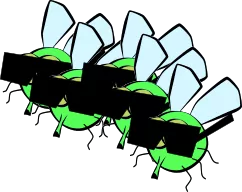

Vamos a hacer un experimento para probar el efecto de la agrupación de parásitos sobre su efectividad. Prepararemos un espacio con los hospedadores situados al azar y lanzaremos sobre ellos varios grupos de parásitos. ¿Cuántos hospedadores se librarán de ser atacados?

Este *script* en **R** lo hace en forma gráfica:

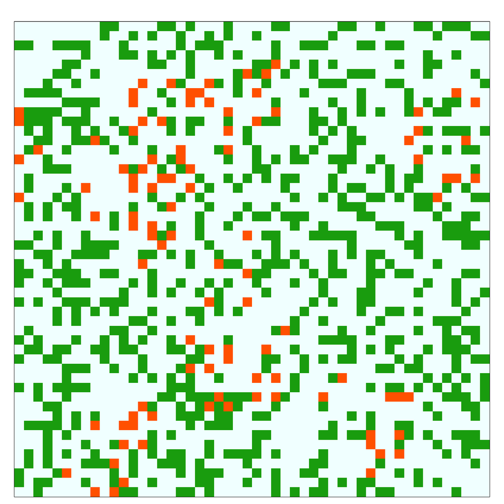

```r
#---- VARIABLES
xmax <- 50                  # ancho pradera
ymax <- 50                  # largo pradera
S <- matrix(0, xmax, ymax)  # posiciones hospedadores
Si <- S                     # p. hosp. inf. por nº picaduras
Sp <- S                     # posiciones hospedador infestado
nH <- 1000                  # número de hospedadores
m <- 8                      # número de grupos
mx <- integer()             # posición x de los grupos
my <- integer()             # posición y de los grupos
n <- 50                     # número de individuos/grupo
nx <- integer()             # posición x de los parásitos
ny <- integer()             # posición y de los parásitos
radio <- 40                 # radio del grupo
nP <- m*n                   # número de parásitos

#---- REPARTO HOSPEDADORES
for (i in 1:nH) {
  x <- sample(1:xmax, 1)
  y <- sample(1:ymax, 1)
  S[x, y] <- 1
}
nHreal <- sum(S)            # número real de hospedadores

#---- REPARTO DE PARÁSITOS
mx <- sample(1:xmax, m)     # centro x gravedad de cada grupo
my <- sample(1:ymax, m)     # centro y gravedad de cada grupo
for (i in 1:m) {            # poblar los m grupos
  for (j in 1:n) {
    fuera <- TRUE
    while (fuera) {
      nx[j] <- sample((mx[i] - radio):(mx[i] + radio), 1)
      ny[j] <- sample((my[i] - radio):(my[i] + radio), 1)
      radij <- (nx[j] - mx[i])^2 + (ny[j] - my[i])^2
      if (radij < radio) {
        fuera <- FALSE
        }
      nx[j] <- nx[j] %% xmax
      if (nx[j] == 0) {
        nx[j] <- 1
      }
      ny[j] <- ny[j] %% ymax
      if (ny[j] == 0) {
        ny[j] <- 1
      }
    }
    if (S[nx[j], ny[j]] == 1) {# ha pillado a un hospedador
      Si[nx[j], ny[j]] <- Si[nx[j], ny[j]] + 1 # suma picadura
      Sp[nx[j], ny[j]] <- 1 # marca picadura
      }
  }
}

#---- RECUENTO DISTRIBUCIÓN PICADURAS
picax <- 0:8
pica <- as.numeric(table(factor(Si, levels = picax)))
pica[1] <- nHreal - sum(pica[2:9])  # calcular H pica = 0
f <- pica[1]/nHreal

#---- RESULTADO GRÁFICO
par(pty = "s", mar = c(0, 1, 1, 1), xaxt = "n", yaxt = "n", xaxs = "i", yaxs="i", ann = FALSE)
S <- S + Sp
image(x = 1:xmax, y = 1:ymax, S, xlim = c(0.5, xmax + 0.5), ylim = c(0.5, ymax + 0.5), col = c("azure", verde, naranja))
```

**Parásitos agrupados.** La distribución de los hospedadores ■ es al azar y los parásitos, aunque no lo parezca a simple vista, atacan en clanes dispuestos aleatoriamente. Los parásitos siguen atacando posiciones del espacio al azar dentro de su grupo pero no siempre encuentran hospedadores. En esta simulación hay $813$ hospedadores atacados por $8$ grupos de $50$ parásitos cada uno. Del total de $400$ parásitos atacantes, solo $104$ han encontrado huésped ■. Esto significa que $f = 0.87$.

> ¿Sale también una distribución de Poisson?

Ahora cabe la duda. Vamos a comprobarlo repitiendo muchas veces el experimento. Para que sea más rápido, se puede reducir a una dimensión y eliminamos la información gráfica.

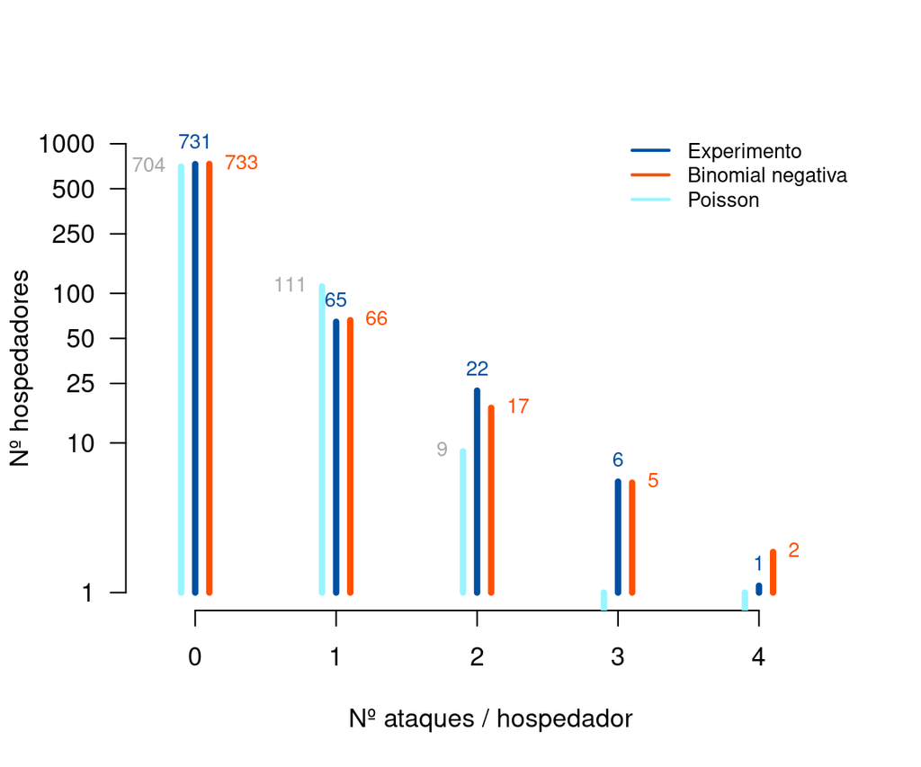

```r
#---- VARIABLES
espacio <- 2500             # espacio total
m <- 8                      # número de grupos
n <- 50                     # número de individuos/grupo
radio <- 40                 # radio del grupo
nH <- 1000                  # número de hospedadores
veces <- 1000               # veces que se repite la simulación
picax <- 0:4                # nº posible de picaduras/hospedador
clases <- length(picax)
picam <- numeric(clases)         # tabla media picaduras

#---- BUCLE DE LAS VECES
for (v in 1:veces){
  S <- integer(espacio)       # posiciones hospedadores
  Si <- S                     # posiciones hospedadores infestados

  #---- REPARTO DE HOSPEDADORES
  S[sample(espacio, nH, replace = TRUE)] <- 1
  nHreal <- sum(S)

  #---- REPARTO DE PARÁSITOS
  mx <- sample(espacio, m, replace = TRUE)    # centro gravedad de cada grupo
  for (i in 1:m) {            # poblar los m grupos
    for (j in 1:n) {
      nx <- sample((mx[i] - radio):(mx[i] + radio), 1)
      nx <- nx %% espacio
      if (nx == 0) {nx <- 1}
      if (S[nx] == 1) { # ha pillado a un hospedador
        Si[nx] <- Si[nx] + 1     # lo marcamos como infestado
      }
    }
  }

  #---- DISTRIBUCIÓN DE PICADURAS
  pica <- as.numeric(table(factor(Si, levels = picax)))
  pica[1] <- nHreal - sum(pica[2:clases])
  picam <- picam + pica

} # fin bucle veces

picam <- picam / veces

#---- RESULTADO GRÁFICO
par(bty = "n", las = 1)
plot(picax, log10(picam), ylim = c(0, log10(nH)), xlim = c(-0.3, clases - 0.5), type = "h", xlab = "Nº ataques / hospedador", ylab = "Nº hospedadores", col =azul, lwd = 4, yaxt = "n")
etiquetas <- c(1, 10, 25, 50, 100, 250, 500, 1000)
axis(2, at = log10(etiquetas), labels = etiquetas)
text(picax, log10(picam), round(picam), cex = 0.8, pos = 3, col = azul)
nHreal <- sum(picam)
media <- sum(picax*picam)/nHreal
varia <- sum(picam*(picax-media)^2)/(nHreal - 1)
poi <- nHreal*dpois(picax, media)
points(picax - 0.1, log10(poi), type = "h", col = "cadetblue1", lwd = 4)
text(picax - .1, log10(poi), round(poi), cex = 0.8, pos = 2, col = "darkgrey")

#---- AJUSTE BINOMIAL
SDC2 <- function(par) { # mínimos cuadrados
  ft <- nHreal*dnbinom(picax, size = par, mu = media)
  SDCn = sum((picam - ft)^2)/(var(picam)*clases)
  return(SDCn)
}
SDC <- function(par) { # mínimo chi2
  ft <- nHreal*dnbinom(picax, size = par, mu = media)
  SDCn = sum(((picam - ft)^2)/ft)
  return(SDCn)
}
ajusteBN <- optim(par = c(0.18), SDC)
k <- ajusteBN$par
ft <- (1 + media/k)^(-k)
pbn <- nHreal*dnbinom(picax, size = k, mu = media)
points(picax + .1, log10(pbn), type = "h", col = naranja, lwd = 4)
text(picax + .1, log10(pbn), round(pbn), cex = 0.8, pos = 4, col = naranja)
legend("topright", c("Experimento", "Binomial negativa", "Poisson"), lty = 1, lwd = 2, col = c(azul, naranja, "cadetblue1"), cex = 0.8, bty = "n")
```

**¡Aparece una binomial negativa!** La distribución experimental de ataques por hospedador, cuando el parásito ataca en grupos, deja de ser de Poisson y se transforma en una binomial negativa. El número medio de ataques por hospedador es $\bar{x} = 0.16$ y la varianza es mayor: $s^2 = 0.24$, lo cual indica la agregación de los ataques e invalida el uso de la distribución de Poisson, donde media y varianza son iguales. La distribución de Poisson se ha calculado directamente a partir de $\mu$ y la binomial negativa con la misma media y el coeficiente $k$ ajustado por optimización numérica (mira el código).

> La distribución de Poisson se convierte en una binomial negativa

El agrupamiento de parásitos aumenta la probabilidad de que el mismo hospedador reciba múltiples ataques y por ello, para el mismo valor medio de ataques ($\mu = a P$, recuerda), el valor de $f$ es ligeramente mayor que el esperado por Poisson.

La binomial negativa tiene una [fórmula un poco enrevesada](https://www.jstor.org/stable/4114), sobre todo, si la queremos expresar en los términos ecológicamente más intuitivos. Menos mal que solo necesitamos $f$, el primer término $\operatorname{P}[X = 0]$ de la distribución:

$$f = \left( 1 + \frac{a P}{k} \right)^{-k}$$
donde $k$ es el coeficiente relacionado inversamente con el grado de agrupamiento. Cuanto mayor sea $k$ más homogénea es la distribución, de hecho, aparece la distribución de Poisson cuando $k$ es muy grande, así que ésta es un caso particular de la binomial negativa. En la práctica, $k$ se puede calcular a partir del exceso de varianza que tiene la distribución BN sobre la Poisson:

$$k \approx \frac{\bar{x}^2}{s^2 - \bar{x}}$$

[interactive chart not shown]

**Valores de $f$ en ambas distribuciones** Para la misma media, la distribución binomial negativa da valores de $f$ mayores que la distribución de Poisson. Este efecto es más acusado cuando $k$ es menor, cosa que se manifiesta en una mayor interferencia entre los parásitos.

> Aplicado a datos reales

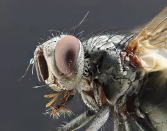

En [este artículo](https://www.jstor.org/stable/3674) R. May, al que ya conocemos de otras veces, defiende este enfoque con datos que le pasó su amigo, el entusiasta entomólogo [Michael Hassell](https://www.royensoc.co.uk/about-us/people/prof-michael-hassell-cbe-frs/) sobre el número de larvas que *Cyzenis albicans* depositaba en *Operophtera brumata*, su polilla hospedadora:

| Nº larvas/polilla | Nº polillas |
| --- | --- |
| 0 | 1066 |
| 1 | 176 |
| 2 | 48 |
| 3 | 8 |
| 4 | 5 |

En aquella época, May y Hassell no disponían de las facilidades que tenemos hoy con **R**, así que le rendimos homenaje repitiendo el cálculo que ellos hicieron en el 78:

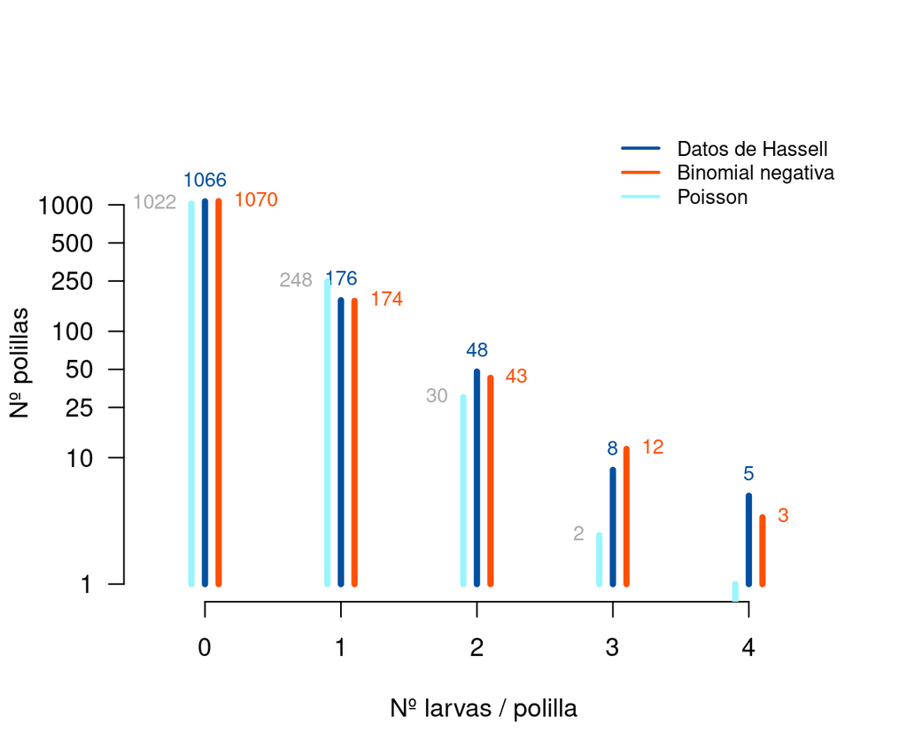

```r
#---- DATOS DE M. HASSELL Y ANÁLISIS DE R. MAY
#---- con Cyzenis albicans
picax <- c(0, 1, 2, 3, 4)
picam <- c(1066, 176, 48, 8, 5)

# Gráfico
par(bty = "n", las = 1)
plot(picax, log10(picam), ylim = c(0, 3.5), xlim = c(-0.4, 4.5), type = "h", xlab = "Nº larvas / polilla", ylab = "Nº polillas", col =azul, lwd = 4, yaxt = "n")
etiquetas <- c(1, 10, 25, 50, 100, 250, 500, 1000)
axis(2, at = log10(etiquetas), labels = etiquetas)
text(picax, log10(picam), round(picam), cex = 0.8, pos = 3, col = azul)
nHreal <- sum(picam)
media <- sum(picax*picam)/nHreal
varia <- sum(picam*(picax-media)^2)/(nHreal - 1)
poi <- nHreal*dpois(picax, media)
points(picax - 0.1, log10(poi), type = "h", col = "cadetblue1", lwd = 4)
text(picax - .1, log10(poi), round(poi), cex = 0.8, pos = 2, col = "darkgrey")

# Ajuste de la binomial (mínimo chi2) y gráfico final
SDC <- function(par) {
  ft <- nHreal*dnbinom(picax, size = par, mu = media)
  SDCn = sum(((picam - ft)^2)/ft)
  return(SDCn)
}
ajusteBN <- optim(par = c(0.18), SDC)
k <- ajusteBN$par
ft <- (1 + media/k)^(-k)
pbn <- nHreal*dnbinom(picax, size = k, mu = media)
points(picax + .1, log10(pbn), type = "h", col = naranja, lwd = 4)
text(picax + .1, log10(pbn), round(pbn), cex = 0.8, pos = 4, col = naranja)
legend("topright", c("Datos de Hassell", "Binomial negativa", "Poisson"), lty = 1, lwd = 2, col = c(azul, naranja, "cadetblue1"), cex = 0.8, bty = "n")
```

**Homenaje a May y Hassell** El número de larvas por polilla que encontró Hassell se ajusta muy bien a una distribución binomial negativa con $\mu = 0.24$ y $k = 0.49$. Aquí seguimos sus pasos basados en el cálculo de $\chi^2$ como describe Thomas Southwood en su libro de métodos que, por cierto, ha sido [revisado recientemente para utilizar **R**](https://academic.oup.com/book/39450). Estimando $k$ como se explica arriba, consiguieron $\chi^2 = 3.60$ y nosotros, con la función `optim` de **R** bajamos a $\chi^2 = 2.64$. En ambos casos, queda clara la validez de la binomial negativa. *¡No se puede decir que las matemáticas fallen en este caso!*

> El sistema es estable si el parásito forma grupos

La interferencia entre los parásitos tiene un desenlace inesperado (*¿o no tanto?*): ¡el sistema es estable!

[interactive chart not shown]

**Figura 6. El sistema es estable si los parásitos forman grupos.** Cuando $k < 1$ el sistema tiene un punto de equilibrio estable. Prueba con distintos valores de los coeficientes y con distintos valores iniciales (punto verde gordo), verás que el equilibrio se consigue más rápidamente cuanto menor sea $k$. La línea verde y la naranja se cruzan en el punto de equilibrio teórico. Como la simulación solo llega hasta 500 generaciones, puede ser que la figura acabe antes de llegar y te parezca un ciclo límite, pero éste solo aparece cuando $k = 1$.

La nuevas ecuaciones que incorporan la posibilidad de agrupamiento son

$$\begin{align}
N_{t+1} &= \lambda N_t \left( 1 + \frac{a P_t}{k} \right)^{-k}\\[1em]
P_{t+1} &= c \lambda N_t \left[1 - \left( 1 + \frac{a P_t}{k} \right)^{-k} \right]
\end{align}$$

## O en un *refugio*

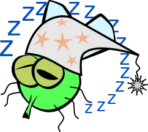

La evolución ha perfeccionado la estrategia de algunos animales, entre ellos muchos insectos, y por supuesto parásitos, con una fase vital que se denomina periodo durmiente o *diapausa*. El animal detiene su metabolismo durante cierto tiempo, que a veces puede ser interminable, en espera de mejores condiciones de vida. Este fenómeno también se ha observado en algunos alumnos durante las clases de Ecología<sub>2</sub>, aunque el decano sostiene que se trata de una leyenda académica.

El caso es que, matemáticamente, este malabarismo temporal se traduce en que siempre habrá un cierto número de parásitos, digamos $R$, expectantes por pillar hospedadores en una buena generación.

Veamos las ecuaciones originales de Nicholson & Bailey incluyendo el nuevo factor:

$$\begin{align}
N_{t+1} &= \lambda N_t e^{-a P_t}\\[1em]
P_{t+1} &= c \lambda N_t \left(1 - e^{-a P_t} \right) + R
\end{align}$$

[interactive chart not shown]

**Figura 7. ¡Los parásitos durmientes estabilizan el sistema!** La sola inclusión de $R$ en la segunda ecuación aporta un equilibrio estable a la convivencia de ambas especies. Como antes, las densidades ideales en equilibrio están en verde y naranja (¡anímate a calcularlas, que son fáciles!) y la línea azul fina representa el refugio para los parásitos. Según el valor de $R$ en relación con los otros coeficientes, en vez de un punto de equilibrio estable, puede aparecer un *ciclo límite*. Prueba con distintos valores y, de paso, sorpréndete con la belleza de algunas combinaciones.

# Parásitos con varias fases

La visión de de Nicholson & Bailey, o de las otras variantes, simplifica el comportamiento del hospedador y el parásito, sin tener en cuenta algunos detalles biológicos que pueden ser interesantes y dar lugar a otros enfoques. Veamos un caso más sofisticado:

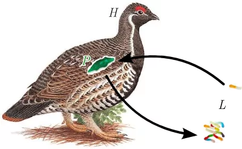

**Figura 8. La perdiz y el nematodo.** Picoteando inocente por el campo, ingiere sin darse cuenta una larva de nematodo (aquí representada por un gusanito de gominola, para no herir sensibilidades). Una vez dentro de su hospedador, el nematodo larva se transforma en parásito adulto, capaz de poner huevos que saldrán por donde te imaginas, para convertirse en larvas libres dispuestas a infestar a otras perdices. Este ciclo es muy habitual en muchos parásitos intestinales de terrorífico aspecto. Un caso como este lo describen con detalles más escabrosos [Dobson & Hudson](https://www.jstor.org/stable/5339) en los páramos escoceses, que vamos a simplificar porque este episodio ya está quedando demasiado largo.

Aquí tenemos algunos detalles biológicos que antes se habían eludido:

- El parásito no mata al hospedador, solo lo explota.
- Las generaciones del hospedador y del parásito no han de estar sincronizadas.
- El parásito puede estar en dos fases, cada una con distinta función.

> Volvemos a las ecuaciones diferenciales

La solución se podría atacar con ecuaciones discretas al estilo *N&B* pero es mucho más fácil definir un sistema con 3 ecuaciones diferenciales, una para el hospedador $H$, otra para las larvas $L$ la última para el número de parásitos $p$ dentro de cada hospedador. Esta última te puede resultar chocante, ¿por qué no usamos $P$, el número total de parásitos? Ya verás al final.

Hay varias formas de interpretar numéricamente la biología que hemos descrito. A ver qué te parece esta:

$$\begin{align}
\frac{dH}{dt} &= (r - \alpha p) H \\[1em]
\frac{dL}{dt} &= \zeta p H - \beta L H \\[1em]
\frac{dp}{dt} &= \beta L - \alpha p^2
\end{align}$$

donde $r$ es la tasa intrínseca de crecimiento del hospedador, $\alpha$ es el menoscabo que causa un parásito a su hospedador, $\beta$ es la capacidad de invasión de las larvas y $\zeta$ el número de larvas que produce cada parásito. Aunque podría haber usado el alfabeto latino también para el parásito, el uso del griego está más que justificado por la forma del coeficiente $\zeta$ ¡que no deja duda sobre lo que representa!

- La primera ecuación representa el crecimiento exponencial del hospedador con una tasa intrínseca $r$ que se ve disminuida en proporción $\alpha$ al número interno de parásitos $p$.
- La segunda expresa el balance de larvas libres: el término positivo es el número de larvas $\zeta$ que produce cada parásito por el número total de estos $p H$ (número de parásitos/hospedador multiplicado por abundancia de hospedadores); el término negativo es la típica acción de masas proporcional a la abundancia de los dos elementos que intervienen y representa la ingestión de larvas libres por los hospedadores.
- La tercera diferencial parece un poco más rara, a pesar de ser también un balance. El término positivo debería corresponder a la salida de la ecuación anterior, $\beta L H$ pero, ojo, como estamos considerando *parásitos/hospedador* hay que dividir esa expresión por $H$ ya así queda explicada. El término negativo se entiende mejor si se escribe $\alpha p · p$, ¿recuerdas que $\alpha p$ es un equivalente a la mortalidad que provoca el parásito en el hospedador? Pues como el parásito, verdaderamente, forma parte del hospedador, también se inflige a sí mismo la misma pérdida.

#### Extraño equilibrio y necesaria modificación

Al igualar las diferenciales a cero aparece el punto de equilibrio para los tres componentes del sistema:

$$\begin{align}
H &= \text{depende de las condiciones iniciales} \\[1em]
L &= \frac{r^2}{\alpha \beta} \\[1em]
p &= \frac{r}{\alpha}
\end{align}$$

pero claro, esto solo funciona cuando $r = \zeta$, que es una condición demasiado fuerte y, unido al extraño comportamiento de $H$, hace que el resultado matemático sea poco creíble biológicamente.

Para ganar un poco de significado biológico solo es necesario considerar que las larvas libres están sometidas a cierta mortalidad $\mu$, así que modficamos la segunda ecuación:

$$\frac{dL}{dt} = \zeta p H - \beta L H - \mu L$$
y entonces todo cobra sentido, ya que el equilibrio se convierte en

$$\begin{align}
H &= \frac{\mu r}{\beta (\zeta - r)} \\[1em]
L &= \frac{r^2}{\alpha \beta} \\[1em]
p &= \frac{r}{\alpha}
\end{align}$$

Observa que debe cumplirse que $\zeta > r$ para que exista un valor de equilibrio para $H$, es decir, la tasa de reproducción intrínseca del parásito debe ser mayor que la del hospedador.

Otra relación curiosa, la que aporta estabilidad al modelo, es que el valor de equilibrio de $H$ depende tanto de la mortalidad $\mu$ de las larvas como de su propia tasa de crecimiento $r$, mientras las larvas en equilibrio dependen de $r^2$. Se puede decir, en cierta forma, que las larvas actúan como el *freno logístico* de la población de hospedadores.

Finalmente, el parásito adulto actúa en realidad como un intermediario numérico entre $H$ y $L$, modulando los valores del potencial $r$ de crecimiento del hospedador y el daño $\alpha$ que acabarán causando las larvas ingeridas por éste.

Veamos estas ecuaciones en acción:

[interactive chart not shown]

**Figura 9. Dinámica de hospedadores, larvas y parásitos.** Con tantos coeficientes es difícil encontrar un patrón de comportamiento. Para empezar, la figura muestra la configuración de las ecuaciones sin mortalidad de larvas, que solo permite el equilibrio si $r = \zeta$. Puedes comprobarlo. Si lo necesitas, puedes hacer zum con la ruedecilla del ratón y mover la gráfica por el recuadro. Si se desmanda la simulación, vuelve a la condiciones iniciales clicando en las flechitas gemelas arriba a la derecha.

## Esto es lo más sencillo que se reparte

El ejemplo es una simplificación del original de Dobson & Hudson que, a su vez, está inspirado en los modelos más generales que desarrollaron R. May y R. Anderson en los 70 (puedes ver una revisión [aquí](https://www.nature.com/articles/280361a0)) que, a su vez, beben de los Elementos de Biología Física de Lotka, como todas las variantes que puedes encontrar del tema.

> Quien evita la tentación…

La ecuaciones todo lo soportan. La relaciones hospedador/parásito son una de las áreas más prolíficas generando matemáticas de todo tipo, todas rigurosas pero algunas con más sentido y otras con menos. Es fácil caer en la tentación de añadir una nueva ecuación, un nuevo coeficiente, un nuevo axioma… en un intento de reproducir la extraordinaria complejidad que la evolución ha inscrito en la biología de estas poblaciones. Nosotros nos quedamos con una conclusión principal: el parásito es capaz de controlar al hospedador cuando se considera explícitamente el espacio o la heterogeneidad que éste induce en la densidad poblacional.

# Ejercicios selectos

## 1. Jeremías «el Cantarillo»

[figure not shown]

Pepe Pérez miraba el punto de fuga donde se unían las infinitas filas de naranjos, preocupado por la hoja que tenía en su mano. Recordó con amargura cuando su abuelo Ozeíllo Pérez estuvo a punto de perder las huertas por culpa del maldito bicho y el *efecto voltereta* que provocó con el *ZZ*. Recordó a su padre, José Pérez, mal aconsejado por los expertos en lucha biológica, gastándose una pasta en *Aphytis melinus*, la avispilla parásita de *Aonidiella aurantii*, la dichosa cochinilla, ¡que fue mucho peor! A cada generación de cochinillas (que podían ser cada dos meses) aumentaban las oscilaciones de ambos insectos hasta que, en un par de años, desapareció la avispa y la cochinilla, a continuación, arrasó los naranjos.

Pepe no sabía qué hacer. Con gran intuición biológica, soltó periódicamente una pequeña cantidad de avispillas, pero éstas no proliferaban si había pocas cochinillas. Parecía que el cortijo de «Los Cántaros» estaba condenado.

Entonces, su hijo Jeremías Pérez, cuarto en la saga de *los Cantarillos*, que fue desheredado por romper la tradición familiar tanto en nombre como oficio al salir a la madre, abandonar el campo y estudiar matemáticas, apareció como todos los veranos y le dio la solución: reservar unas cuantas hojas con cochinillas y soltarlas cuando escasearan.

En su desesperación, Pepe hizo caso a su hijo, como último recurso y… ¡funcionó! A pesar de tener cochinillas todo el año, también se mantuvieron las avispas y el número de naranjos afectados era muy limitado.

*¿Cómo sabía Jeremías que aquella solución era la única posible?*

## 2. Las naranjas de Huffaker

[figure not shown]

Después de leer a Gause, el entomólogo californiano Carl Huffaker pensó que las condiciones ideales del ambiente homogéneo eran demasiado *ideales* y diseñó una serie de minuciosos experimentos con el ácaro fitófago *Eotetranychus sexmaculatus* y su depredador el también ácaro *Typhlodromus occidentalis*.

Les preparó varios universos a base de planetas-naranja separados cierta distancia, a veces con obstáculos. En algunos estos mundos heterogéneos, Huffaker encontró con gran satisfacción que las poblaciones de depredadores y presas podían oscilar sin extinguirse (salvo por agotamiento del sustrato), cosa que Gause, por más que se empeñó, no consiguió en sus matraces. Huffaker [publicó su experimento en Hilgardia](https://hilgardia.ucanr.edu/fileaccess.cfm?article=152469&p=JTWUMP), la revista local de la estación experimental agraria de su universidad, Berkely. A pesar de la humilde editorial, es uno de los artículos de ecología más citados como ejemplo de diseño experimental.

Imagina que haces el mismo experimento con hospedadores y parásitos que, como hemos visto, no se distinguen matemáticamente de depredadores y presas. Puedes reducirlo al mínimo imprescindible:

- Dos naranjas
- En cada generación, una fracción de la población de hospedadores y parásitos se cambia de naranja.

Utiliza las ecuaciones originales de Nicholson & Bailey. Una hoja de cálculo te permitirá comprobar, estupefacto, que *¡el sistema formado por las dos naranjas es estable!*

## 3. Turismo sotenible en *Fekete-Város*

[figure not shown]

El alcaide de Fekete-Város, una oscura aldea de la Europa profunda que apenas había avanzado desde la Edad Media, ya se había doblegado a la idea de perder el pueblo, uno más en la *Europa vaciada*, cuando recibió la vista de un misterioso experto en turismo rural.

Cubierto por una capa que la grasienta lluvia no había conseguido empapar, de tez mortecina y labios tan rojos y finos y que parecían cortes de navaja, se tuvo que encorvar para traspasar el dintel de la puerta del bar, a la sazón, ayuntamiento y notaría.

―Buenas tardes ―dijo el alcaide con una vez trémula, afectado por la singular figura del visitante.

―Buenas tardes, amigo ―retumbó una voz tan impropia de aquella angosta boca que pareció salir de detrás del forastero, aullada por el viento.

―U…usted dira…á ―balbuceó el alcaide.

―Me llamo Vladimiro Cienfuegos von Banderillas, laureado en la universidad de Transilvania, máster en Turismo Azul Sostenible Circular Aplicado y Gestión Ambiental Onerosa por la universidad de Cartago y diplomado en *soft skills* y técnicas suavonas por la *International Association of Professional & Unqualified Charlatans of Hamilton, Illinois* ―susurró con una voz mitad erudita mitad gutural.

―¿Sabusté? ―expelió el alcaide un poco más recuperado del susto inicial e impresionado por el currículo del experto― ¡A ver qué se pue’jacé con el pueblo pa’charlo p’alante!

―Le propongo un negocio ―contestó mientras acercaba tanto el rostro al alcaide que casi le clava el pico de viudo, negro azabache y delineado con el mismo bisturí que los labios.

―El futuro es el *turismo rural medieval escenográfico* ―siguió Vladimiro arrullando las palabras que salían hipnóticas de su garganta insondable, con los párpados tan cerrados que solo podían perforarlos las dos centellas de sus pupilas―. En una visita con nada incluido, el turista se ve inmerso en el medioevo oscuro, rodeado de *experiencias vitales inigualables* y no duda lo más mínimo en dejarse el último florín. Fueraparte lo que sacará el consistorio de la conversión de chozas en apartamentos turísticos.

―Suena bien ―dijo el inocente alcaide, que se mostró solícito― ¿Un anisete?

―No, gracias, es *muy temprano* para mí ―objetó el visitante y entonces puso el contrato delante de los codiciosos ojos del otro.

―¿Tiene un boli? ―preguntó ansioso el alcaide.

―Esto servirá ―musitó Vladimiro mientras le ofrecía la mano y daba un zarpazo en la palma del que iba a estrecharla.

―¡Iop***! ―gritó el alcaide con un respingo y manchó el contrato con la sangre que le brotó de su diestra.

―Así está bien ―sentenció Vladimiro volviéndose hacia la puerta.

En lo que tardó el alcaide en rodear la mesa y correr hacia la calle, el enigmático fautor había volado, dejando al edil tan atónito como aterrado. La campana de la iglesia dobló entonces el primero de doce lúgubres tañidos.

El alcaide pasó una noche agitada empapado en sudores fríos y, más repuesto por la mañana, creyó que había tenido una pesadilla. Cuando se dispuso a desayunar su habitual rebaná cateta con ajo y aceite, vio aterrorizado el contrato sobre el mostrador de bar. Iba coger el pergamino cuando lo sobresaltó una algarabía procedente de la calle.

Seis extranjeros ataviados con ropajes estrafalarios y pertrechados con todo tipo de *i‑*chalauras y otros *gadgets* turísticos se hacían *selfies* masivos en la puerta del bar.

―¡Esto funciona! ―gritó el alcaide, que enseguida perdió el miedo con el olor a divisas. Y entró como una exhalación a ejercer su labor de restaurador, con tanta vehemencia, que hizo volar el contrato hasta debajo de la máquina del café. Si te he visto no me acuerdo.

```r
                        C O N T R A T O
                        ###############

1) Cada día llegará un número fijo de turistas, el que se quiera,

2) Los turistas serán advertidos de que pueden quedar tan impac-
   tados que al finalizar la estancia solo sentirán que han
   tenido la experiencia de sus vidas, pero no recordarán los
   detalles.

2) Todos los turistas tendrán que pasar la noche en el pueblo.

3) Nadie podrá entrar en la escuela.  Total, para lo que sirve.

4) No se admiten reclamaciones.
```

Después de la primera noche, uno de los turistas se quejó porque le habían picado dos mosquitos en el cuello. El alcaide le regaló un *afterbite* y se congratuló al ver a seis nuevos turistas haciendo cola en la puerta del establecimiento. Al día siguiente había más víctimas de los mosquitos, así que mandó al mancebo a por una garrafa de amoníaco, rellenó unos *widgets* molones con la propaganda del pueblo y andado. Aparecieron 6 nuevos turistas.

El alcaide notó un extraño comportamiento en los turistas más veteranos que habían sufrido las picaduras. Se volvían casquivanos y pasaban ya de los monumentos medievales, dedicándose a trasegar *palinka* a troche y moche, formando corrillos de borrachos que, en cierto modo, daban vida a un pueblo que estaba a pique de perecer. Lo extraño es que, la última noche que pasaban los turistas en el pueblo, desaparecían por completo. Y al día siguiente, aparecían en su estado original, eso sí, con la sensación de haber tenido una experiencia vital sin par.

Al cabo de unas semanas, los pocos lugareños que quedaban en *Fekete-Város* se tuvieron que acostumbrar las bandadas de beodos y al ambiente depravado para beber de la nueva fuente de riqueza. *«Orines por florines»*, tal como rezaba el cuarto principio del decálogo turístico universal.

> ¿Puedes imaginarte lo que pasaba en Fekete-Város?

Aquí tienes unas pistas:

- ¿Por qué *era demasiado temprano* para el anisete, según Vladimiro?
- ¿Por qué no le *picaban los mosquitos* al alcaide?
- ¿Por qué tenían que pasar la noche en el pueblo?
- ¿Por qué estaba prohibido ir al colegio?
- ¿Qué beneficio sacaba Vladimiro?